# Data Viz FINAL!

Data Visualization (STAT 302)

Anna Wagman

### Introduction:

As an avid Netflix consumer and lover of entertainment, I examined data about the titles available of Netflix. Throughout these visualizations, I explore the relative amounts of Movies vs TV Shows, and then compare specific variables between the two such as “listed_in” and “duration”. I created two distinct visualizations displaying the streaming availability around the world. I extract specific variables such as “date_added” and “country” to explore metrics and changes over time. Throughout my seven explorations, I will highlight key data and statistics about the content on Netflix  
Data source: https://www.kaggle.com/shivamb/netflix-shows**

# Visualization 1: Total Movies & TV Shows per Country

### Q1: What Countries have the most content? Is there a large disparity?

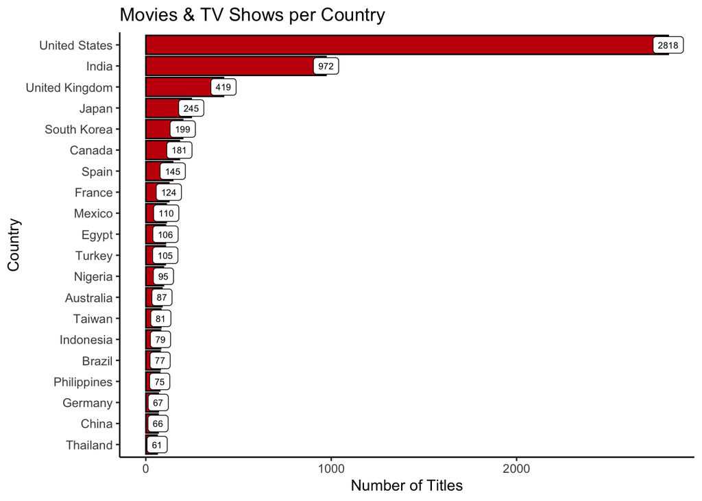

```r
countries_plot
```

## Plot 1b. World Map of Available content

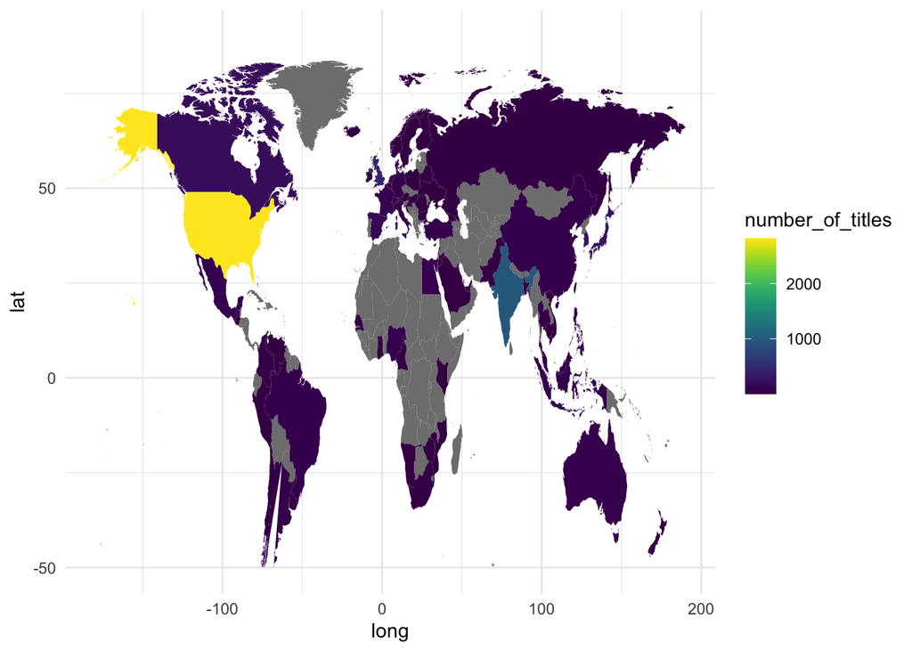

```r
netflix_world_map
```

# Visualization 2: Movies vs TV shows

### Q2. Does Netflix have more Movies or TV Shows? What is the difference?

```r
Amount_MvT
```

```
## # A tibble: 2 × 2
##   type    number_of_each
##   <chr>            <int>
## 1 Movie             6131
## 2 TV Show           2676
```

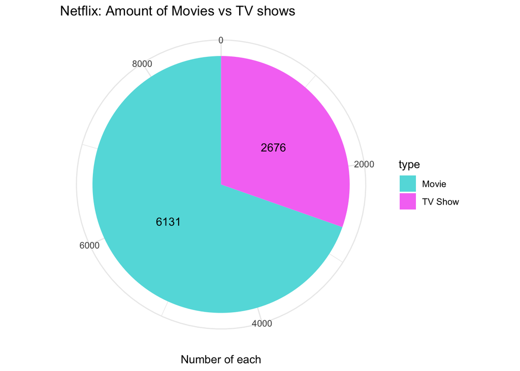

```r
MvT_plot
```

# Visualization 3: Amount of titles over time

### Q3. How many titles get added each year? Has it been increasing or decreasing over time?

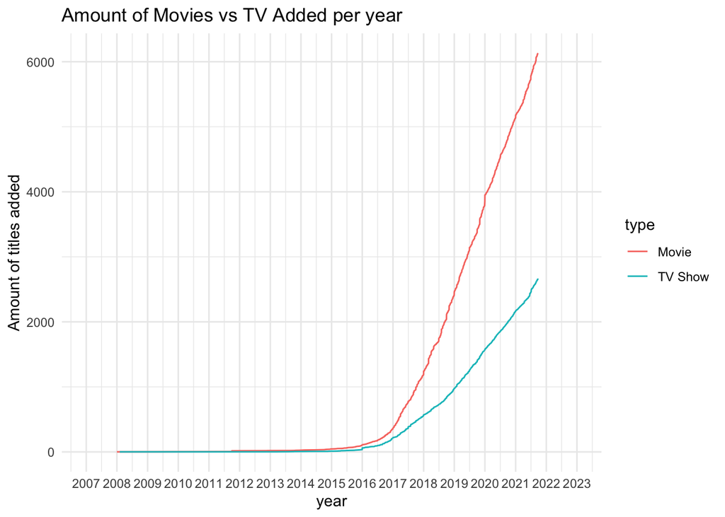

```r
added_plot
```

# Visualization 4: Genres of Movies and TV Shows

### Q4. What are the most common genres of Netflix? Are the Genres different for Movies vs TV Shows?

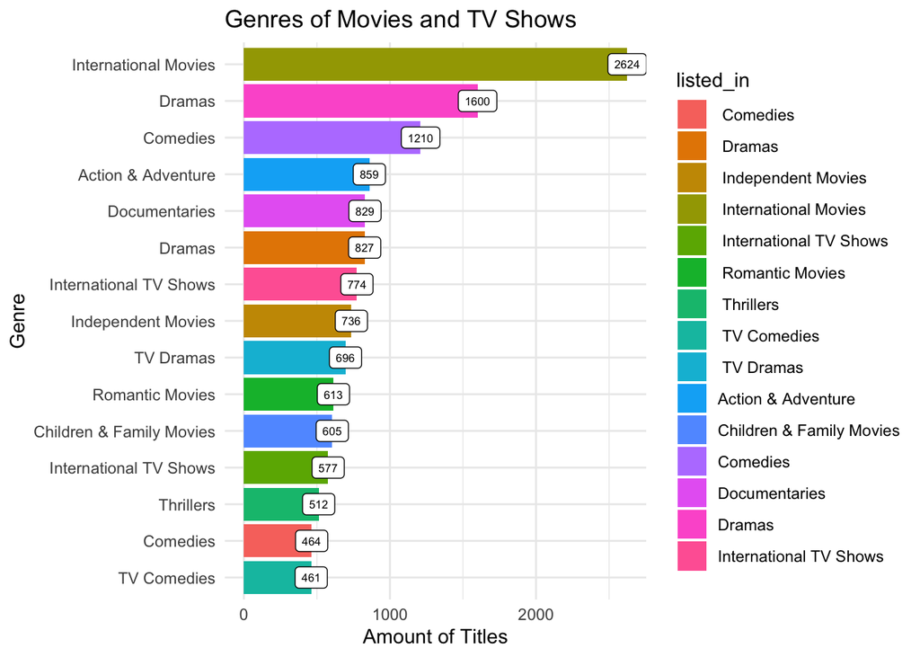

```r
MvT_Genres
```

## Plot 4b: Genres of Movies vs TV Shows (compared)

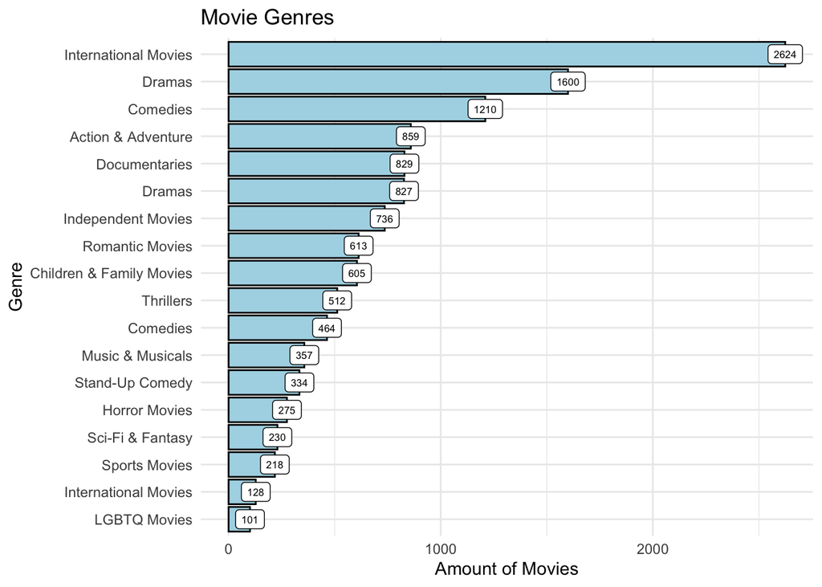

```r
Movie_Genres
```

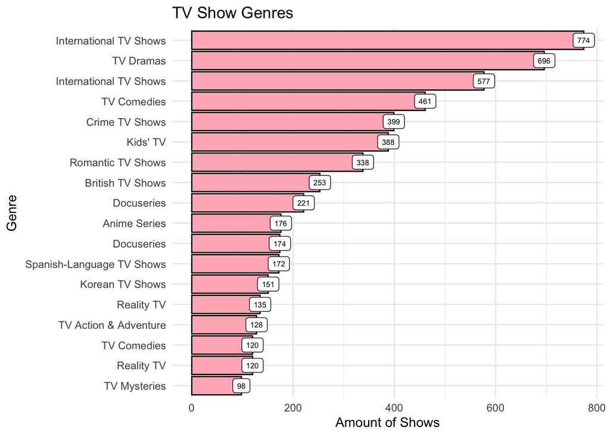

```r
TV_Genres
```

# Visualization 5: Release Date vs Date Added

### Q5. How long after something is released is it added to Netflix? Is it usually within the year?

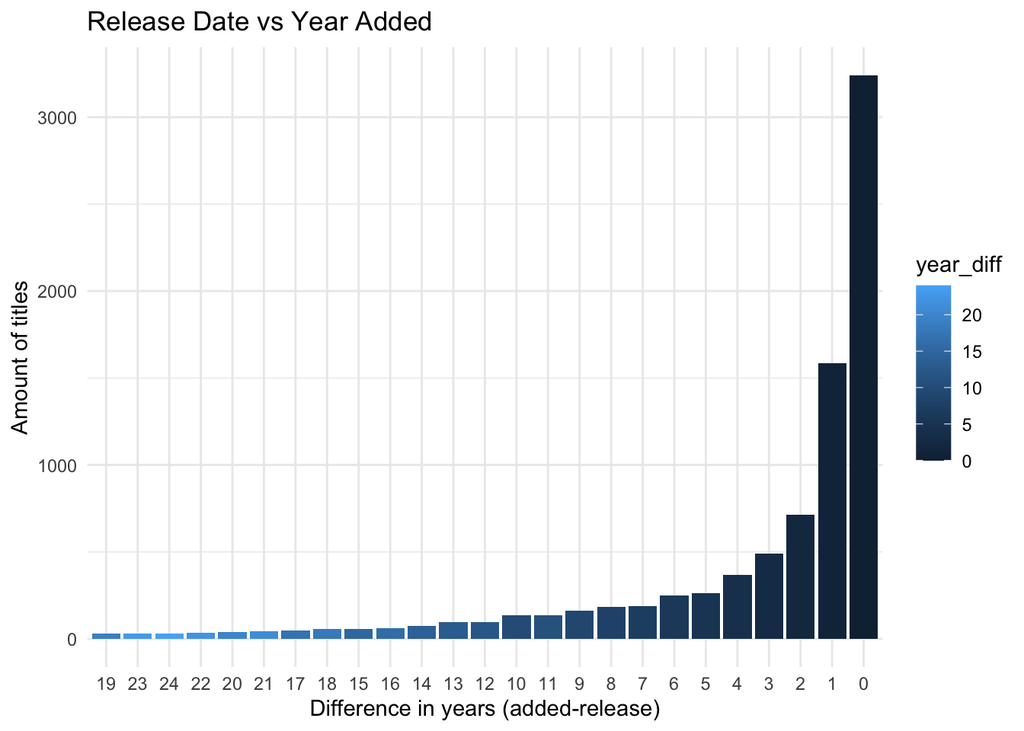

```r
netflix_dates2
```

# Visualization 6: Notable Directors & Actresses/Actors

### Q6. Who are the most frequence Directors on Netflix? With how many films? Who are the most frequent Actresses and Actors?

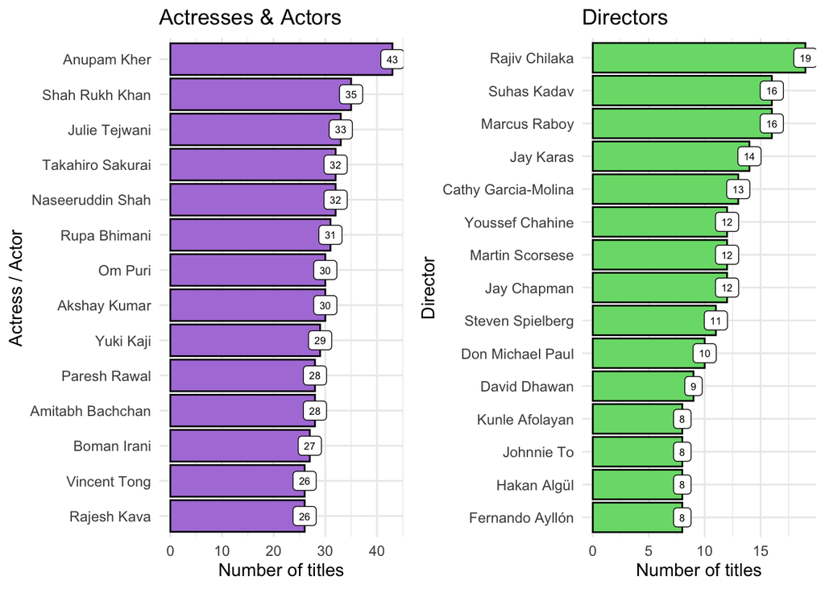

```r
plot_grid(actors_plot, directors)
```

# Visualization 7. TV Shows with the most seasons

### Q7. Which TV shows on netflix have the most seasons? How many seasons are there of that show?

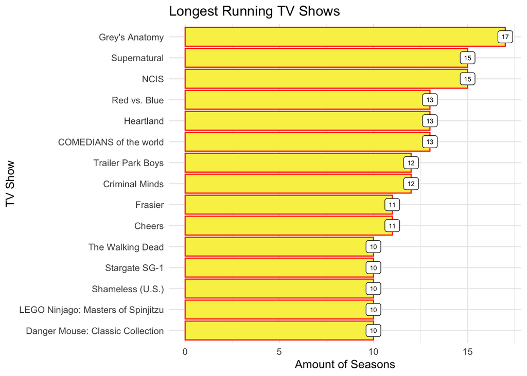

```r
netflix_seasons
```